# Changepoint Analysis For Fatigue Data

## 2.2 Implementation of Several Outlier Detection Methods

### 2.2.1 Boxplots for Outlier Detection

One of the most commonly used approaches for univariate outliers are defined to be the observations that lie outside $1.5 * IQR$, where the IQR is the inter quartile range. This can be easily implemented using in base **R** using the boxplot.stats function. Below, we first provide the output and data plots for each person.

```r
# We are reading the data locally (you can download the file from GitHub)
load(file = "./Data/RGenerated/FeatureGeneration.RData")
outliers_bp <- list() # initilizing a list to store outliers per participant
for (i in 1:15) {
  df <- get(paste0("subject",i,"_features")) # Getting Data from Sec.
  # Obtaining the Outliers for each of the three variables
  out_vals_sl<- boxplot.stats(df[,2])$out
  out_rows_sl <- which(df[,2] %in% out_vals_sl)
  out_vals_sh<- boxplot.stats(df[,3])$out
  out_rows_sh <- which(df[,3] %in% out_vals_sh)
  out_vals_sd<- boxplot.stats(df[,4])$out
  out_rows_sd <- which(df[,4] %in% out_vals_sd)
  # Generating a union set of all obs. that have outliers
  # True: if any of the 3 vars for that obs. is an outlier
  outliers_total <- unique(c(out_rows_sl, out_rows_sh,
                             out_rows_sd))
  outliers_bp[[i]] <- outliers_total # saving it to list indexed by participant number

  # Remove the observations corresponding to the outliers
  assign(paste0("subject",i,"_bp"),
         df[-outliers_total,])

  # Preparing the data for the Line Graph
  df_transformed <- melt(get(paste0("subject",i,"_bp")),
                         id.vars = "time.from.start",
                         measure.vars=c("scaled.stride.len",
                                        "scaled.stride.height",
                                        "stride.duration"
                                        )
                         ) # ggplot data needs to be tall

  assign(paste0("g",i),
         ggplot(data = df_transformed,
                aes(x=time.from.start, y=value, group=variable,
                    color=variable,shape=variable)) +
           geom_line() + theme_bw() + ylim(0,2) +
           ggtitle("Outliers removed via the standard boxplot method \n (any point outside of 1.5*IQR was removed)") +
           theme(legend.position="right",
                 axis.text.x=element_text(angle=90,hjust=1),
                 plot.title = element_text(hjust = 0.5)) +
           facet_wrap(~variable,nrow=1)
         )
  cat('####',paste0("P", i), "{-}",'\n')


    # Printing the % of outliers removed
    cat("\n")
    num_rows <- nrow(get(paste0("subject",i,"_features")))
    num_outliers <- length(outliers_total)
    percent_data <- round(100*num_outliers/num_rows,2)
    cat("<b>",paste0("% of removed Observations for Partcipant ",i,
                 ": ", percent_data,"%."), "</b>",
        "This removes any value outside 1.5 * IQR for any of the 3 features. From the code, it should be clear that we are implementing this columnwise, starting with stride length and ending with stride duration.")
    cat('\n \n')
  # Plotting the data without the outliers
  print(get(paste0("g",i)))
  cat('\n \n')

  cat('<source> <p> Based on the 15 charts above, one can see that using the standard boxplot approach for removing the outliers have resulted in a smoother time-series for all participants. However, the percentage of observations removed as a function of this application is high (i.e. >= 10) for partcipants 6-7, 10, 11-13 and 15. Note that for these participants, the percentage was always under 15%, with the exception of participant 11 who had 23.66% of his/her\'s observation removed as a function of this approach. <b>This obviously represents an unacceptable amount of data lost, and as such we will examine additional methods for removing/detecting outliers. </b> \n \n </p> </source>')

cat('<source> <p>
We could have tried making the value of the coefficient multiplied by the IQR coefficient larger (e.g., both the <i>tsoutlier() function</i> in the <a href="https://cran.r-project.org/web/packages/forecast/forecast.pdf">forecast package</a> and the <i> iqr() function </i> in the <a href="https://cran.r-project.org/web/packages/anomalize/anomalize.pdf">anomalize package</a> use a value of 3 for the coefficient); however, we did not explore this option since this: (a) would have possibly required a large amount of trial-and-error, and (b) the approach would be difficult to justify. </p> </source>')

cat(' \n \n')
}
```

#### P1

**% of removed Observations for Partcipant 1: 7.51%.** This removes any value outside 1.5 * IQR for any of the 3 features. From the code, it should be clear that we are implementing this columnwise, starting with stride length and ending with stride duration.

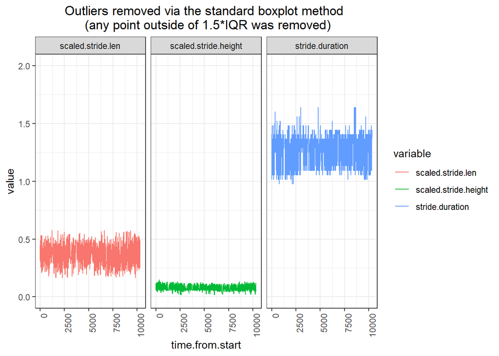

We could have tried making the value of the coefficient multiplied by the IQR coefficient larger (e.g., both the *tsoutlier() function* in the forecast package and the *iqr() function* in the anomalize package use a value of 3 for the coefficient); however, we did not explore this option since this: (a) would have possibly required a large amount of trial-and-error, and (b) the approach would be difficult to justify.

#### P2

**% of removed Observations for Partcipant 2: 5.75%.** This removes any value outside 1.5 * IQR for any of the 3 features. From the code, it should be clear that we are implementing this columnwise, starting with stride length and ending with stride duration.

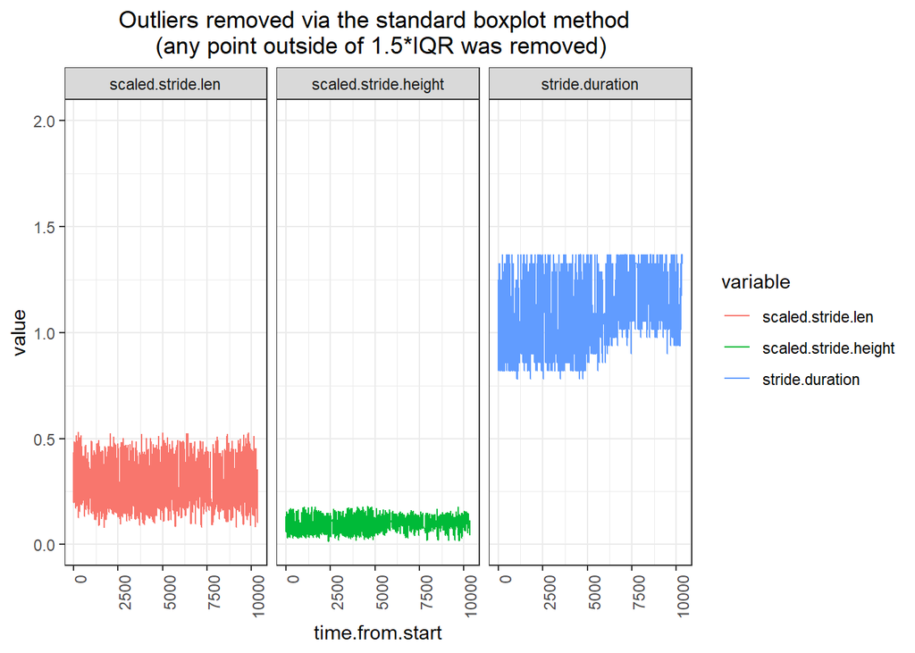

We could have tried making the value of the coefficient multiplied by the IQR coefficient larger (e.g., both the *tsoutlier() function* in the forecast package and the *iqr() function* in the anomalize package use a value of 3 for the coefficient); however, we did not explore this option since this: (a) would have possibly required a large amount of trial-and-error, and (b) the approach would be difficult to justify.